# Programacion Funcional

Práctica Guiada

```r
library(fs)
library(tidyverse)
library(openxlsx)
library(glue)
```

### Ejemplo 1: Iterando en la EPH

Lo primero que necesitamos es definir un vector o lista sobre el que iterar.

Por ejemplo, podemos armar un vector con los path a las bases individuales, con el comando `fs::dir_ls`

```r
bases_individuales_path <- dir_ls(path = '../../Fuentes/', regexp= 'individual')
bases_individuales_path
```

```
../../Fuentes/usu_individual_t117.txt ../../Fuentes/usu_individual_t216.txt ../../Fuentes/usu_individual_t316.txt
../../Fuentes/usu_individual_t416.txt
```

Luego, como en la función que usamos para leer las bases definimos muchos parametros, nos podemos armar una función *wrapper* que sólo necesite un parámetro, y que simplifique la escritura del map

```r
leer_base_eph <- function(path) {
  read.table(path,sep=";", dec=",", header = TRUE, fill = TRUE) %>%
    select(ANO4,TRIMESTRE,REGION,P21,CH04, CH06)
}

bases_df <- tibble(bases_individuales_path) %>%
  mutate(base = map(bases_individuales_path, leer_base_eph))
```

```r
bases_df
```

| bases_individuales_path | base |
| --- | --- |
| ../../Fuentes/usu_individual_t117.txt |  |
| ../../Fuentes/usu_individual_t216.txt |  |
| ../../Fuentes/usu_individual_t316.txt |  |
| ../../Fuentes/usu_individual_t416.txt |  |

El resultado es un DF donde la columna **base** tiene en cada fila, otro DF con la base de la EPH de ese período. Esto es lo que llamamos un *nested DF* o dataframe nesteado pa les pibes.

Si queremos juntar todo, podemos usar `unnest()`

```r
bases_df <- bases_df %>% unnest()
bases_df
```

| bases_individuales_path | ANO4 | TRIMESTRE | REGION | P21 | CH04 | CH06 |
| --- | --- | --- | --- | --- | --- | --- |
| ../../Fuentes/usu_individual_t117.txt | 2017 | 1 | 43 | 0 | 2 | 18 |
| ../../Fuentes/usu_individual_t117.txt | 2017 | 1 | 43 | 0 | 2 | 13 |
| ../../Fuentes/usu_individual_t117.txt | 2017 | 1 | 43 | 0 | 1 | 15 |
| ../../Fuentes/usu_individual_t117.txt | 2017 | 1 | 43 | 0 | 2 | 11 |
| ../../Fuentes/usu_individual_t117.txt | 2017 | 1 | 43 | 0 | 1 | 7 |
| ../../Fuentes/usu_individual_t117.txt | 2017 | 1 | 43 | 0 | 2 | 4 |
| ../../Fuentes/usu_individual_t117.txt | 2017 | 1 | 43 | 0 | 2 | 17 |
| ../../Fuentes/usu_individual_t117.txt | 2017 | 1 | 43 | 0 | 1 | 1 |
| ../../Fuentes/usu_individual_t117.txt | 2017 | 1 | 43 | 1500 | 1 | 20 |
| ../../Fuentes/usu_individual_t117.txt | 2017 | 1 | 43 | 0 | 2 | 1 |

[output cut: 990 more lines]

> ¿Qué pasa si los DF que tenemos nesteados no tienen la misma cantidad de columnas?

Esto mismo lo podemos usar para fragmentar el datastet por alguna variable, con el `group_by()`

```r
bases_df %>%
  group_by(REGION) %>%
  nest()
```

| REGION | data |
| --- | --- |
| 43 |  |
| 41 |  |
| 44 |  |
| 42 |  |
| 40 |  |
| 1 |  |

```r
NA
```

Así, para cada región tenemos un DF.

> ¿ De qué sirve todo esto?

No todo en la vida es un Dataframe. Hay estucturas de datos que no se pueden normalizar a filas y columnas. En esos casos recurríamos tradicionalmente a los loops. Con MAP podemos tener los elementos agrupados en un sólo objeto y aún conservar sus formas diferentes.

### Ejemplo 2: Gráficos en serie

El objetivo de este ejercicio es hacer un gráfico por país de forma automática.

- Primero veamos los datos

```r
library(gapminder)


gapminder_unfiltered %>%
  sample_n(10)
```

| country | continent | year | lifeExp | pop | gdpPercap |
| --- | --- | --- | --- | --- | --- |
| Taiwan | Asia | 1971 | 69.100 | 14918496 | 3652.2035 |
| Bahamas | Americas | 1997 | 68.472 | 281577 | 20990.8325 |
| Bulgaria | Europe | 1990 | 71.310 | 8894028 | 7225.8780 |
| Gambia | Africa | 1987 | 49.265 | 848406 | 611.6589 |
| Malawi | Africa | 1982 | 45.642 | 6502825 | 632.8039 |
| Colombia | Americas | 1972 | 61.623 | 22542890 | 3264.6600 |
| Albania | Europe | 1962 | 64.820 | 1728137 | 2312.8890 |
| Jamaica | Americas | 1962 | 65.610 | 1665128 | 5246.1075 |
| Canada | Americas | 1993 | 77.830 | 28920644 | 26590.3994 |
| Pakistan | Asia | 1982 | 56.158 | 91462088 | 1443.4298 |

```r
NA
```

la base tiene la siguiente info:

- country: Nombre del país
- continent: Nombre del continente
- year: año
- lifeExp: Esperanza de vida al nacer
- pop: Población
- gdpPercap
- Vamos a hacer un gráfico sencillo para Argentina

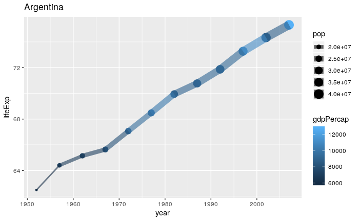

```r
data_argentina <- gapminder_unfiltered %>%
  filter(country=='Argentina')

ggplot(data_argentina, aes(year, lifeExp, size= pop, color=gdpPercap))+
  geom_point()+
  geom_line(alpha=0.6)+
  labs(title = unique(data_argentina$country))
```

- Ahora que tenemos una idea de lo que queremos gráficar lo podemos poner adentro de una función que grafique.

```r
# definimos la función
graficar_pais <- function(data, pais){

  ggplot(data, aes(year, lifeExp, size= pop, color=gdpPercap))+
    geom_point()+
    geom_line(alpha=0.6)+
    labs(title = pais)
}
```

probamos la función para un caso

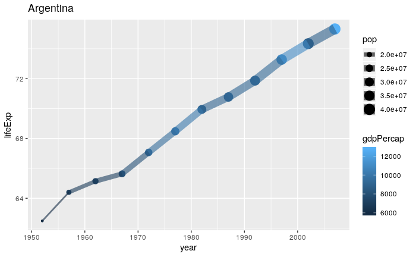

```r
graficar_pais(data_argentina, 'Argentina')
```

- Nos armamos un dataset nesteado

```r
gapminder_nest <- gapminder_unfiltered %>%
  group_by(country) %>%
  nest()
gapminder_nest[1:5,]
```

| country | data |
| --- | --- |
| Afghanistan |  |
| Albania |  |
| Algeria |  |
| Angola |  |
| Argentina |  |

```r
NA
```

- Ahora podemos crear una nueva columna que contenga los gráficos

```r
gapminder_nest <- gapminder_nest %>%
  mutate(grafico= map2(.x = data, .y = country,.f =  graficar_pais))

gapminder_nest[1:5,]
```

| country | data | grafico |
| --- | --- | --- |
| Afghanistan |  |  |
| Albania |  |  |
| Algeria |  |  |
| Angola |  |  |
| Argentina |  |  |

Veamos un ejemplo

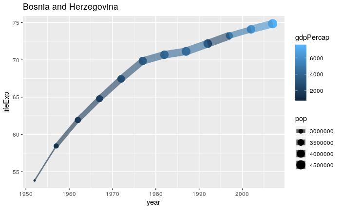

```r
gapminder_nest$grafico[21]
```

Ahora podemos guardar todos los gráficos en un archivo PDF

```r
pdf('../../Resultados/graficos_gapminder.pdf')
gapminder_nest$grafico
dev.off()
```